# Peer Assessment 1 — Activity monitoring data

LLCP

June 14, 2015

## Loading and preprocessing the data

The data has been preprocess using dplyr library, dplyr provides a flexible grammar of data manipulation

```r
library(dplyr)
data <- read.csv(file = "activity.csv", as.is = TRUE)
data <- tbl_df(data)
```

## What is mean total number of steps taken per day?

First, I calculate the total number of steps group by day

```r
data_question_1 <- data %>%
                         group_by(date) %>%
                         summarise(stepsByDay= sum(steps, na.rm = T))
```

Then, I plot the histogram for the **data_question_1** already compute:

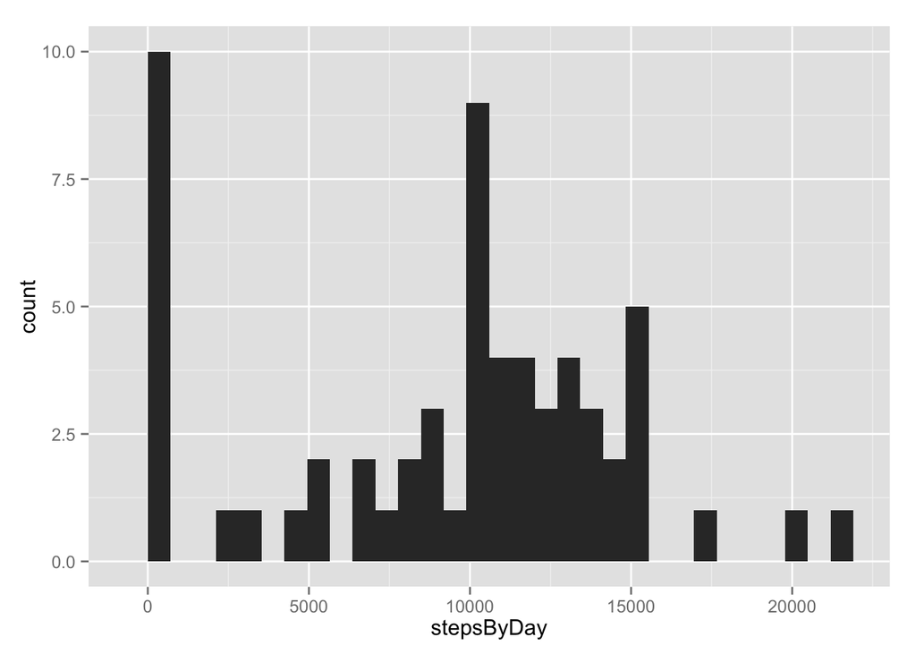

```r
library(ggplot2)
qplot(stepsByDay, data=data_question_1, geom= "histogram")
```

Finally, I calculate and report the mean and median of the total number of steps taken per day:

```r
mean(data_question_1$stepsByDay)
```

```
## [1] 9354.23
```

```r
median(data_question_1$stepsByDay)
```

```
## [1] 10395
```

## What is the average daily activity pattern?

First, I calculate the mean number of steps group by interval

```r
data_question_2 <- data %>%
                         group_by(interval) %>%
                         summarise(stepsByInterval= mean(steps, na.rm = T))
```

Then, I plot the 5-minute interval average number of steps taken, to show the daily pattern:

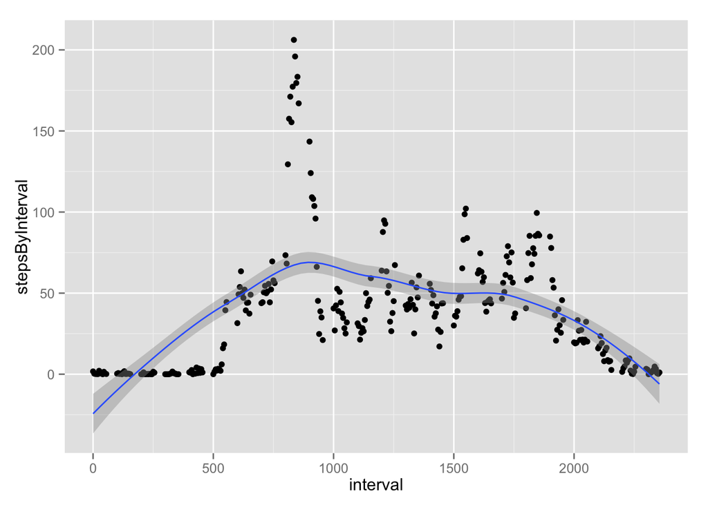

```r
qplot(interval, stepsByInterval, data=data_question_2, geom=c("point", "smooth"))
```

Which 5-minute interval, on average across all the days in the dataset, contains the maximum number of steps?

```r
data_question_2 %>% filter( stepsByInterval == max(stepsByInterval))
```

```
## Source: local data frame [1 x 2]
##
##   interval stepsByInterval
## 1      835        206.1698
```

## Imputing missing values

The presence of missing days may introduce bias into some calculations or summaries of the data. I will calculate and report the total number of missing values in the dataset

```r
sum(is.na(data$steps))
```

```
## [1] 2304
```

The strategy for filling the missing values in the dataset is filling that value with the mean for that 5-minute interval. Let’s do it! I already have the mean 5-minute interval in the **data_question_2** dataset

```r
data_question_3 <- left_join(data, data_question_2) %>%
                  mutate(fill.steps = ifelse(is.na(steps), stepsByInterval, steps)) %>%
                  select(date, interval, fill.steps)
```

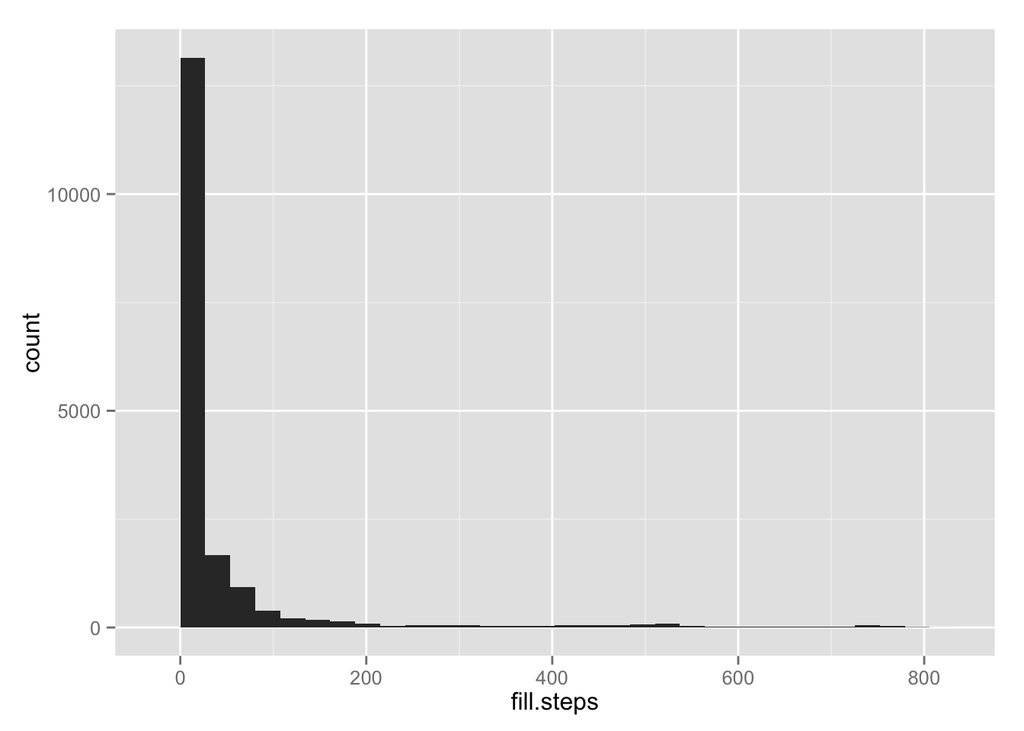

```r
qplot(fill.steps, data=data_question_3, geom= "histogram")
```

```r
mean(data_question_3$fill.steps)
```

```
## [1] 37.3826
```

```r
median(data_question_3$fill.steps)
```

```
## [1] 0
```

Do these values differ from the estimates from the first part of the assignment? Sure, lets look how much they differ

```r
mean(data_question_1$stepsByDay) - mean(data_question_3$fill.steps)
```

```
## [1] 9316.847
```

```r
median(data_question_1$stepsByDay) - median(data_question_3$fill.steps)
```

```
## [1] 10395
```

## Are there differences in activity patterns between weekdays and weekends?

I create a new variable in the dataset with two values – “weekday” and “weekend” indicating whether a given date is a weekday or weekend day.

```r
data_question_4 <- data %>% mutate(day =weekdays(as.Date(data$date))) %>%
                  mutate(weekday = ifelse((day == "Sunday" | day == "Saturday"),"weekend", "weekday"))

data_question_4 <- data_question_4 %>%
                  select(steps, date, interval, weekday) %>%
                  group_by(weekday, interval) %>%
                  summarise(stepsByInterval= mean(steps, na.rm = T))
```

Let’s see if there is any difference in the between weekday and weekend

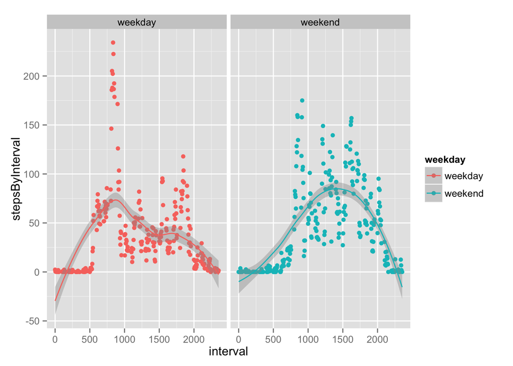

```r
qplot(interval, stepsByInterval,
      data=data_question_4, facets=.~weekday,
      geom=c("point","smooth"), color=weekday)
```